# Mini Project 6

```r
pro_canc <- read.csv(file = "prostate_cancer.csv", header=TRUE, sep=",")
attach(pro_canc)
```

When seeing the boxplot below for the dataset, the variance is high. So we are performing log transformation.

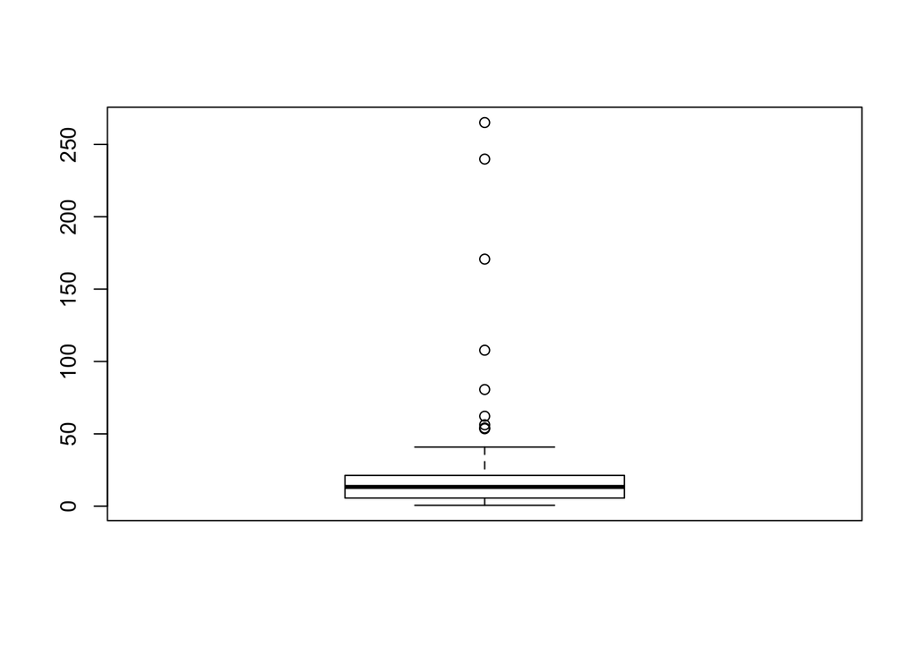

```r
boxplot(pro_canc$psa)
```

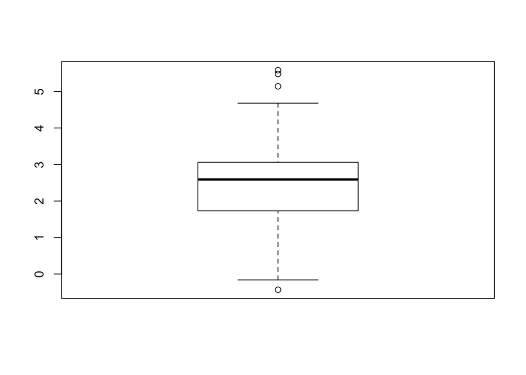

```r
y <- log(pro_canc$psa, base = exp(1))
boxplot(y)
```

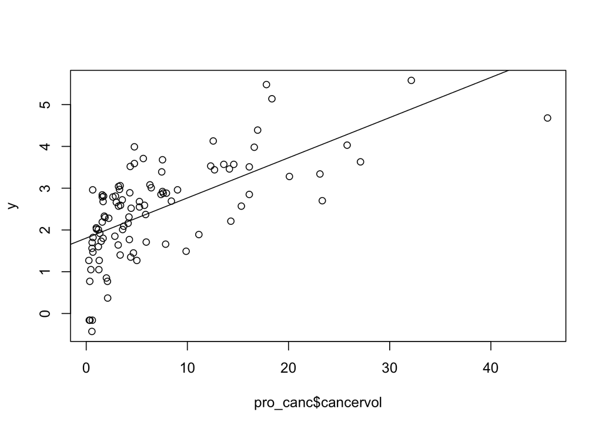

```r
plot(pro_canc$cancervol, y)
fit1 <- lm(y ~ cancervol, data = pro_canc)
abline(fit1)
```

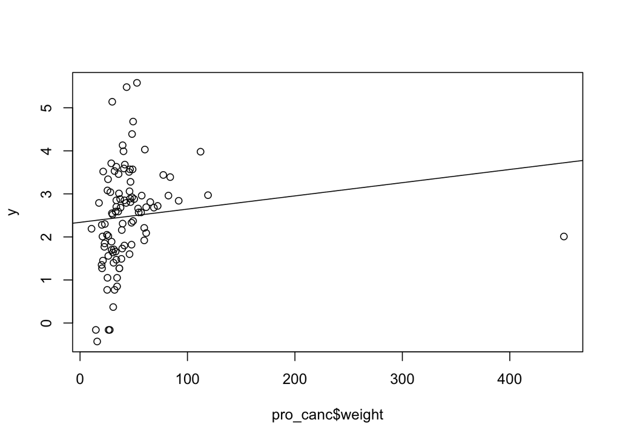

```r
plot(pro_canc$weight, y)
fit2 <- lm(y ~ weight, data = pro_canc)
abline(fit2)
```

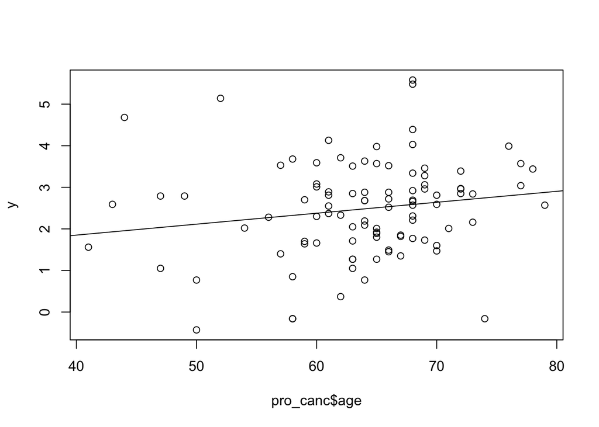

```r
plot(pro_canc$age, y)
fit3 <- lm(y ~ age, data = pro_canc)
abline(fit3)
```

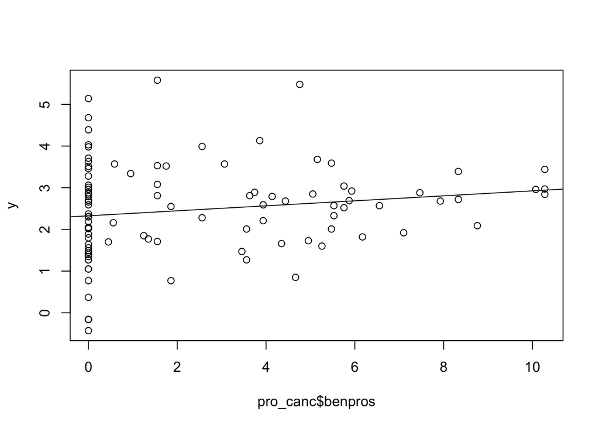

```r
plot(pro_canc$benpros, y)
fit4 <- lm(y ~ benpros, data = pro_canc)
abline(fit4)
```

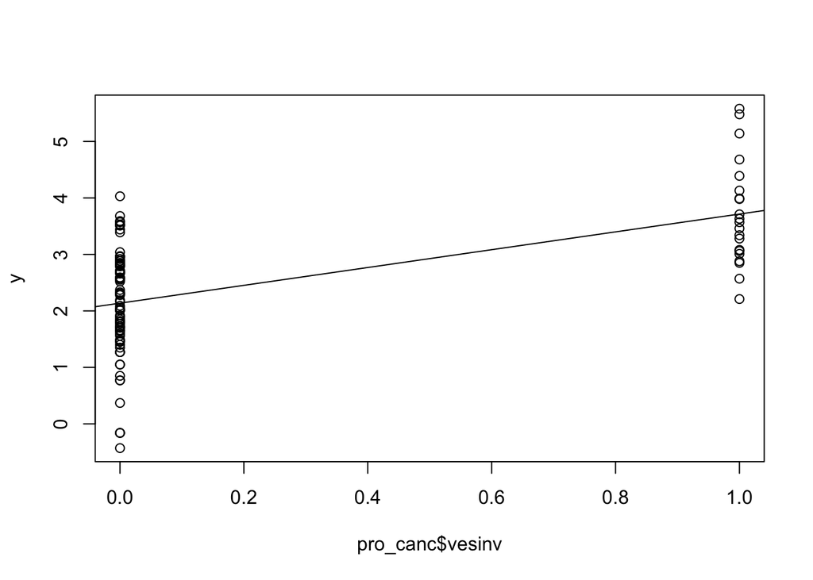

```r
plot(pro_canc$vesinv, y)
fit5 <- lm(y ~ factor(vesinv), data = pro_canc)
abline(fit5)
```

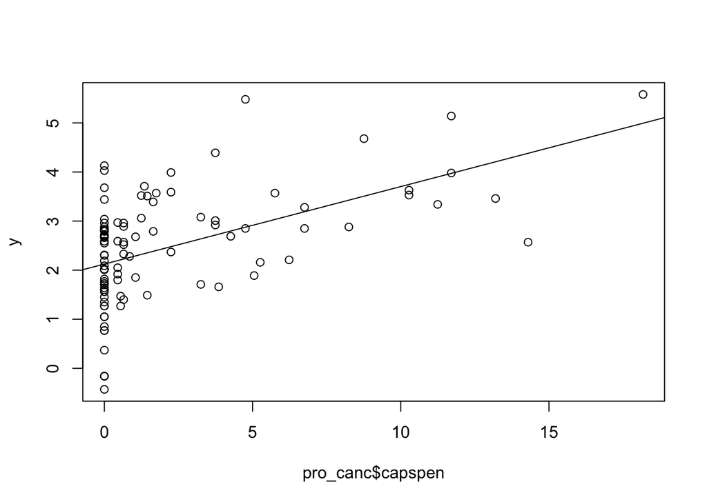

```r
plot(pro_canc$capspen, y)
fit6 <- lm(y ~ capspen, data = pro_canc)
abline(fit6)
```

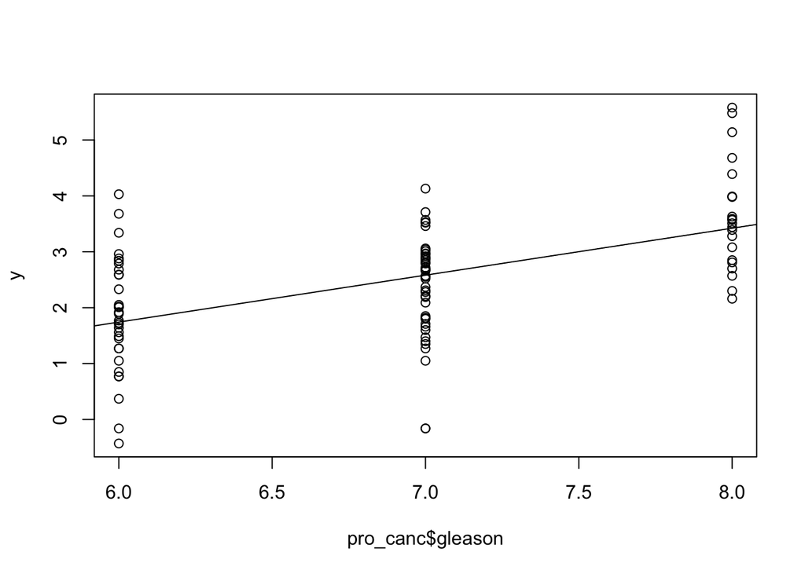

```r
plot(pro_canc$gleason, y)
fit7 <- lm(y ~ gleason, data = pro_canc)
abline(fit7)
```

```r
cor(y, pro_canc$cancervol)
```

```
## [1] 0.6570739
```

```r
cor(y, pro_canc$vesinv)
```

```
## [1] 0.5663641
```

```r
cor(y, pro_canc$gleason)
```

```
## [1] 0.5390167
```

```r
cor(y, pro_canc$capspen)
```

```
## [1] 0.5180231
```

```r
cor(y, pro_canc$age)
```

```
## [1] 0.1699068
```

```r
cor(y, pro_canc$benpros)
```

```
## [1] 0.1574016
```

```r
cor(y, pro_canc$weight)
```

```
## [1] 0.1217208
```

From the plots of individual predictors , the predictors are ordered in decreasing order of their significance with their correlation values listed above

Now ANOVA analysis is performed by adding predictors one by one

```r
fit8 <- lm(y ~ cancervol+ factor(vesinv), data = pro_canc)
anova(fit1,fit8)
```

|  | Res.Df | RSS | Df | Sum of Sq | F | Pr(>F) |
| --- | --- | --- | --- | --- | --- | --- |
| 1 | 95 | 72.60508 | NA | NA | NA | NA |
| 2 | 94 | 66.05825 | 1 | 6.546833 | 9.316056 | 0.002953357 |

```r
summary(fit1)
```

```
##
## Call:
## lm(formula = y ~ cancervol, data = pro_canc)
##
## Residuals:
##     Min      1Q  Median      3Q     Max
## -2.2886 -0.6590  0.1493  0.5769  1.9610
##
## Coefficients:
##             Estimate Std. Error t value Pr(>|t|)
## (Intercept)  1.80549    0.11899  15.174  < 2e-16 ***
## cancervol    0.09619    0.01132   8.496 2.69e-13 ***
## ---
## Signif. codes:  0 '***' 0.001 '**' 0.01 '*' 0.05 '.' 0.1 ' ' 1
##
## Residual standard error: 0.8742 on 95 degrees of freedom
## Multiple R-squared:  0.4317, Adjusted R-squared:  0.4258
## F-statistic: 72.18 on 1 and 95 DF,  p-value: 2.688e-13
```

```r
summary(fit8)
```

```
##
## Call:
## lm(formula = y ~ cancervol + factor(vesinv), data = pro_canc)
##
## Residuals:
##     Min      1Q  Median      3Q     Max
## -2.2733 -0.6265  0.1197  0.6409  1.6097
##
## Coefficients:
##                 Estimate Std. Error t value Pr(>|t|)
## (Intercept)      1.80346    0.11410  15.806  < 2e-16 ***
## cancervol        0.07249    0.01335   5.431 4.38e-07 ***
## factor(vesinv)1  0.77552    0.25408   3.052  0.00295 **
## ---
## Signif. codes:  0 '***' 0.001 '**' 0.01 '*' 0.05 '.' 0.1 ' ' 1
##
## Residual standard error: 0.8383 on 94 degrees of freedom
## Multiple R-squared:  0.483,  Adjusted R-squared:  0.472
## F-statistic: 43.91 on 2 and 94 DF,  p-value: 3.425e-14
```

From the aboves summary data of fit 1 and fit 8, we can see that adjusted R-squared for fit8 > fit1. So we keep fit8 for further analysis. Now we continue the ANOVA analysis for next predictor

```r
fit9 <- lm(y ~ cancervol+ factor(vesinv)+ gleason, data = pro_canc)
anova(fit8,fit9)
```

|  | Res.Df | RSS | Df | Sum of Sq | F | Pr(>F) |
| --- | --- | --- | --- | --- | --- | --- |
| 1 | 94 | 66.05825 | NA | NA | NA | NA |
| 2 | 93 | 60.34039 | 1 | 5.717857 | 8.812682 | 0.003804243 |

We can see that the p-value is less than 0.05 on adding gleason to model, so gleason is a significant predictor.

```r
summary(fit9)
```

```
##
## Call:
## lm(formula = y ~ cancervol + factor(vesinv) + gleason, data = pro_canc)
##
## Residuals:
##      Min       1Q   Median       3Q      Max
## -2.16928 -0.44558  0.08431  0.60719  1.64082
##
## Coefficients:
##                 Estimate Std. Error t value Pr(>|t|)
## (Intercept)     -0.72120    0.85749  -0.841   0.4025
## cancervol        0.05981    0.01352   4.425 2.62e-05 ***
## factor(vesinv)1  0.62117    0.24962   2.488   0.0146 *
## gleason          0.38491    0.12966   2.969   0.0038 **
## ---
## Signif. codes:  0 '***' 0.001 '**' 0.01 '*' 0.05 '.' 0.1 ' ' 1
##
## Residual standard error: 0.8055 on 93 degrees of freedom
## Multiple R-squared:  0.5277, Adjusted R-squared:  0.5125
## F-statistic: 34.64 on 3 and 93 DF,  p-value: 4.022e-15
```

Also, we can see that Adjusted R-squared for fit9 > fit8, so we can retain fit 9 for further analysis.

```r
fit10 <- lm(y ~ cancervol+ factor(vesinv) + gleason + capspen, data = pro_canc)
anova(fit9,fit10)
```

|  | Res.Df | RSS | Df | Sum of Sq | F | Pr(>F) |
| --- | --- | --- | --- | --- | --- | --- |
| 1 | 93 | 60.34039 | NA | NA | NA | NA |
| 2 | 92 | 60.03905 | 1 | 0.3013349 | 0.4617463 | 0.4985151 |

We can see that p-value > 0.05 so capspen is not significant to add in the model. Therefore fit9 is retained for further analysis.

```r
fit11 <- lm(y ~ cancervol+ factor(vesinv)  + gleason + age, data = pro_canc)
anova(fit9,fit11)
```

|  | Res.Df | RSS | Df | Sum of Sq | F | Pr(>F) |
| --- | --- | --- | --- | --- | --- | --- |
| 1 | 93 | 60.34039 | NA | NA | NA | NA |
| 2 | 92 | 59.63474 | 1 | 0.7056537 | 1.08863 | 0.299509 |

We can see that p-value > 0.05 for age as well. So age is not significant to add in the model. We will keep fit9 and proceed with other predictors.

```r
fit12 <- lm(y ~ cancervol+ factor(vesinv)  + gleason + benpros, data = pro_canc)
anova(fit9,fit12)
```

|  | Res.Df | RSS | Df | Sum of Sq | F | Pr(>F) |
| --- | --- | --- | --- | --- | --- | --- |
| 1 | 93 | 60.34039 | NA | NA | NA | NA |
| 2 | 92 | 53.22893 | 1 | 7.111461 | 12.29133 | 0.0007054258 |

We can see that P- value is less than 0.05 so benpros is significant in the model.

```r
summary(fit12)
```

```
##
## Call:
## lm(formula = y ~ cancervol + factor(vesinv) + gleason + benpros,
##     data = pro_canc)
##
## Residuals:
##      Min       1Q   Median       3Q      Max
## -1.88531 -0.50276  0.09885  0.53687  1.56621
##
## Coefficients:
##                 Estimate Std. Error t value Pr(>|t|)
## (Intercept)     -0.65013    0.80999  -0.803 0.424253
## cancervol        0.06488    0.01285   5.051 2.22e-06 ***
## factor(vesinv)1  0.68421    0.23640   2.894 0.004746 **
## gleason          0.33376    0.12331   2.707 0.008100 **
## benpros          0.09136    0.02606   3.506 0.000705 ***
## ---
## Signif. codes:  0 '***' 0.001 '**' 0.01 '*' 0.05 '.' 0.1 ' ' 1
##
## Residual standard error: 0.7606 on 92 degrees of freedom
## Multiple R-squared:  0.5834, Adjusted R-squared:  0.5653
## F-statistic: 32.21 on 4 and 92 DF,  p-value: < 2.2e-16
```

But the value of Adjusted R-squared for fit12 > fit9. So we will continue analysis with fit12.

```r
fit13 <- lm(y ~ cancervol+ factor(vesinv)  + gleason + benpros + weight, data = pro_canc)
anova(fit12,fit13)
```

|  | Res.Df | RSS | Df | Sum of Sq | F | Pr(>F) |
| --- | --- | --- | --- | --- | --- | --- |
| 1 | 92 | 53.22893 | NA | NA | NA | NA |
| 2 | 91 | 52.89833 | 1 | 0.3306002 | 0.5687252 | 0.452713 |

We can see that p-value > 0.05 thus weight is not significant to add in the model. From the above analysis we can see that fit12 is the best model.

Now we will verify the above result by comparing fit12=lm(y ~ cancervol+ factor(vesinv) + gleason + benpros, data = pro_canc) with automatic stepwise model selection procedures based on AIC

```r
fit12.forward <- step(lm(y ~ 1, data = pro_canc),scope = list(upper = ~cancervol + factor(vesinv) + gleason + benpros + weight + age + capspen),direction ="forward")
```

```
## Start:  AIC=28.72
## y ~ 1
##
##                  Df Sum of Sq     RSS      AIC
## + cancervol       1    55.164  72.605 -24.0986
## + factor(vesinv)  1    40.984  86.785  -6.7944
## + gleason         1    37.122  90.647  -2.5707
## + capspen         1    34.286  93.482   0.4169
## + age             1     3.688 124.080  27.8831
## + benpros         1     3.166 124.603  28.2911
## <none>                        127.769  28.7246
## + weight          1     1.893 125.876  29.2767
##
## Step:  AIC=-24.1
## y ~ cancervol
##
##                  Df Sum of Sq    RSS     AIC
## + gleason         1    8.2468 64.358 -33.794
## + benpros         1    7.8034 64.802 -33.128
## + factor(vesinv)  1    6.5468 66.058 -31.265
## + age             1    2.6615 69.944 -25.721
## + weight          1    1.7901 70.815 -24.520
## <none>                        72.605 -24.099
## + capspen         1    0.9673 71.638 -23.400
##
## Step:  AIC=-33.79
## y ~ cancervol + gleason
##
##                  Df Sum of Sq    RSS     AIC
## + benpros         1    6.2827 58.075 -41.758
## + factor(vesinv)  1    4.0178 60.340 -38.047
## + weight          1    2.0334 62.325 -34.908
## <none>                        64.358 -33.794
## + age             1    0.9611 63.397 -33.253
## + capspen         1    0.1685 64.190 -32.048
##
## Step:  AIC=-41.76
## y ~ cancervol + gleason + benpros
##
##                  Df Sum of Sq    RSS     AIC
## + factor(vesinv)  1    4.8466 53.229 -48.211
## <none>                        58.075 -41.758
## + weight          1    0.4006 57.675 -40.429
## + capspen         1    0.1863 57.889 -40.069
## + age             1    0.0059 58.070 -39.768
##
## Step:  AIC=-48.21
## y ~ cancervol + gleason + benpros + factor(vesinv)
##
##           Df Sum of Sq    RSS     AIC
## <none>                 53.229 -48.211
## + capspen  1   0.39230 52.837 -46.928
## + weight   1   0.33060 52.898 -46.815
## + age      1   0.02497 53.204 -46.256
```

From above, we can see that y ~ cancervol + gleason + benpros + factor(vesinv) is the best model from AIC feed forward. This confirms the results obtained by the manual computation of best model.

Model assumptions verification:

Residual plot for fit 12 -

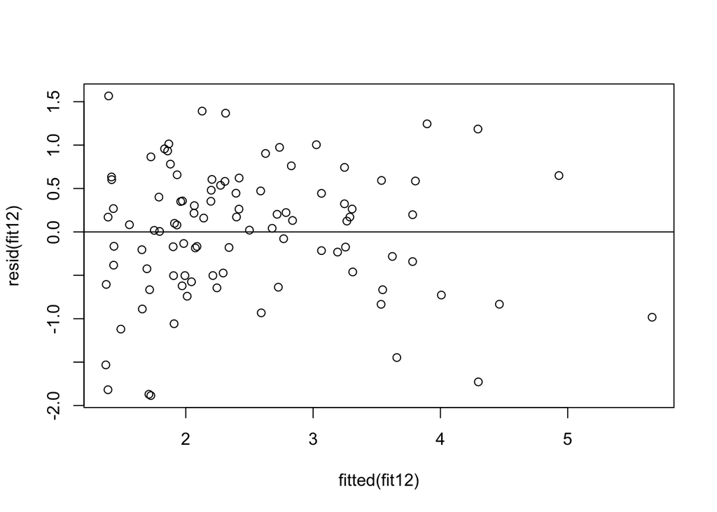

```r
plot(fitted(fit12), resid(fit12))
abline(h=0)
```

The residual plot shows constant variability.

QQ-Plot for fit12 -

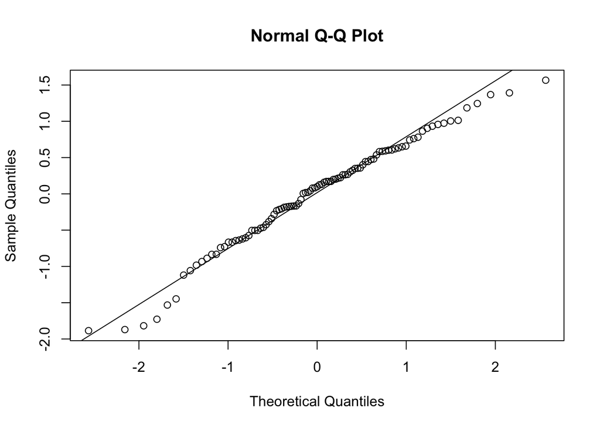

```r
qqnorm(resid(fit12))
qqline(resid(fit12))
```

The QQ-Plot verifies the normality assumption.

Prediction of PSA level of patients.

The best model identified is fit12 <- lm(y ~ cancervol+ factor(vesinv) + gleason + benpros, data = pro_canc)

Here cancervol, gleason and benpros are quantitative variables whereas vesinv is a categorical attribute.

The most frequent category of vesinv is calculated as below.

```r
table(vesinv)
```

```
## vesinv
##  0  1
## 76 21
```

0 is the most frequent category.

For the other attributes we use mean to calculate predicted value.

```r
summary(fit12)
```

```
##
## Call:
## lm(formula = y ~ cancervol + factor(vesinv) + gleason + benpros,
##     data = pro_canc)
##
## Residuals:
##      Min       1Q   Median       3Q      Max
## -1.88531 -0.50276  0.09885  0.53687  1.56621
##
## Coefficients:
##                 Estimate Std. Error t value Pr(>|t|)
## (Intercept)     -0.65013    0.80999  -0.803 0.424253
## cancervol        0.06488    0.01285   5.051 2.22e-06 ***
## factor(vesinv)1  0.68421    0.23640   2.894 0.004746 **
## gleason          0.33376    0.12331   2.707 0.008100 **
## benpros          0.09136    0.02606   3.506 0.000705 ***
## ---
## Signif. codes:  0 '***' 0.001 '**' 0.01 '*' 0.05 '.' 0.1 ' ' 1
##
## Residual standard error: 0.7606 on 92 degrees of freedom
## Multiple R-squared:  0.5834, Adjusted R-squared:  0.5653
## F-statistic: 32.21 on 4 and 92 DF,  p-value: < 2.2e-16
```

The prediction using fit12 model is done as below.

```r
exp(-0.65013 + 0.06488*mean(cancervol) + 0.68*0 + 0.33376*mean(gleason) + 0.09136*mean(benpros))
```

```
## [1] 10.28357
```